# SD_11_RECO_REV_ADD_L2ABCD

Lines 2a through 2d · Amount report

## Overview

**Description**

Total amounts; add lines 2a through 2d

**Table**

`SD-P11-T00-RECONCILIATION-REVENUE` (one)

**Location code**

`SCHED-D-PART-11-LINE-02E`

**Family**

`SCHED-D-PART-11-LINE-02E`

**Data type**

numeric (xsd: , USAmountType)

**Scope**

PC

**Status**

unreviewed

3

xpaths mapped (2 observed)

1,054,272

filings with a value

2009–2024

tax years observed

3

open flags (2 errors)

## Flags

| Severity | Flag | Xpath | Detail |
| --- | --- | --- | --- |
| ⚠ error | `POLARITY` | IRS990ScheduleD/RevenueNotReportedAmt | negated element ‘RevenueNotReportedAmt’ pooled with non-negated xpaths |
| ⚠ error | `POLARITY` | IRS990ScheduleD/RevenueNotRptdF990 | negated element ‘RevenueNotRptdF990’ pooled with non-negated xpaths |
| ⓘ info | `UNOBSERVED` | IRS990ScheduleD/Form990ScheduleDPartXII/TotalAmountsLine2aTo2d | never observed in TY2009-2024 filings |

## Xpaths

All mapped xpaths (under /Return/ReturnData or /Return/ReturnHeader), oldest first. Charts label each series by its xpath.

| Xpath | Form | Chart label | First year | Last year | Versions | Filings | Repeats in |
| --- | --- | --- | --- | --- | --- | --- | --- |
| IRS990ScheduleD/RevenueNotRptdF990 | Sched D | same | 2009 | 2012 | 18 | 178,018 | 0.0% |
| IRS990ScheduleD/RevenueNotReportedAmt | Sched D | same | 2013 | 2024 | 37 | 876,254 | 0.0% |
| IRS990ScheduleD/Form990ScheduleDPartXII/TotalAmountsLine2aTo2d | Sched D | …0ScheduleD/Form990ScheduleDPartXII/TotalAmountsLine2aTo2d |  |  |  | 0 |  |

## Coverage

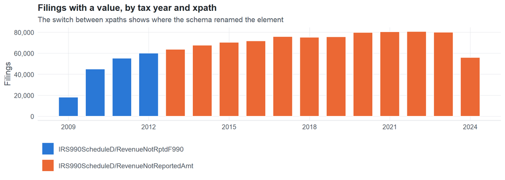

**Table view**

Table view: filings by tax year and series

| Tax year | IRS990ScheduleD/RevenueNotRptdF990 | IRS990ScheduleD/RevenueNotReportedAmt |
| --- | --- | --- |
| 2009 | 18,048 | 0 |
| 2010 | 44,923 | 0 |
| 2011 | 55,135 | 0 |
| 2012 | 59,912 | 0 |
| 2013 | 0 | 63,755 |
| 2014 | 0 | 67,658 |
| 2015 | 0 | 70,352 |
| 2016 | 0 | 71,602 |
| 2017 | 0 | 75,814 |
| 2018 | 0 | 75,130 |
| 2019 | 0 | 75,537 |
| 2020 | 0 | 79,786 |
| 2021 | 0 | 80,355 |
| 2022 | 0 | 80,537 |
| 2023 | 0 | 79,850 |
| 2024 | 0 | 55,878 |

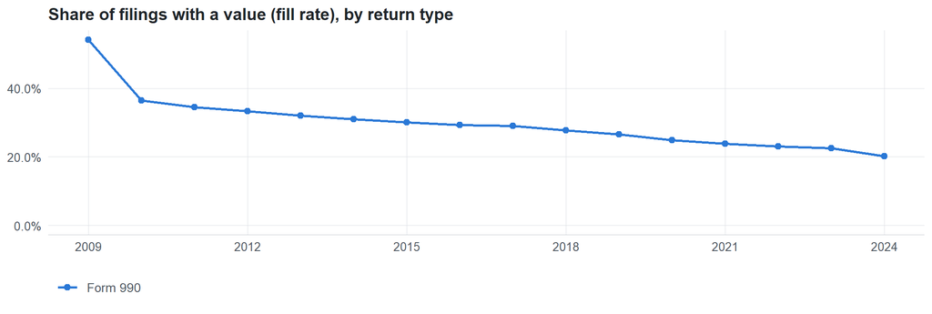

**Table view**

Table view: fill rate

| Tax year | Return type | Filings | All filings | Fill rate |
| --- | --- | --- | --- | --- |
| 2009 | Form 990 | 18,048 | 33,311 | 54.18% |
| 2010 | Form 990 | 44,923 | 123,025 | 36.52% |
| 2011 | Form 990 | 55,135 | 159,504 | 34.57% |
| 2012 | Form 990 | 59,912 | 179,688 | 33.34% |
| 2013 | Form 990 | 63,755 | 198,855 | 32.06% |
| 2014 | Form 990 | 67,658 | 218,619 | 30.95% |
| 2015 | Form 990 | 70,352 | 233,519 | 30.13% |
| 2016 | Form 990 | 71,602 | 243,903 | 29.36% |
| 2017 | Form 990 | 75,814 | 261,612 | 28.98% |
| 2018 | Form 990 | 75,130 | 271,442 | 27.68% |
| 2019 | Form 990 | 75,537 | 283,694 | 26.63% |
| 2020 | Form 990 | 79,786 | 320,342 | 24.91% |
| 2021 | Form 990 | 80,355 | 336,480 | 23.88% |
| 2022 | Form 990 | 80,537 | 349,055 | 23.07% |
| 2023 | Form 990 | 79,850 | 354,768 | 22.51% |
| 2024 | Form 990 | 55,878 | 277,298 | 20.15% |

## Values

| Result | Check | Detail |
| --- | --- | --- |
| ✓ pass | Values parse as numbers | 100.0% of values are numeric |
| ▲ warn | No sudden change in the median between adjacent years | largest change 26.8x (IRS990ScheduleD/RevenueNotReportedAmt, 990, TY2014) |
| ✓ pass | Pooled xpaths are on the same scale (same return type) | largest ratio of medians between xpaths: 1.5x |
| ⓘ info | Sign convention | 14.5% of values are negative (fine for net amounts) |

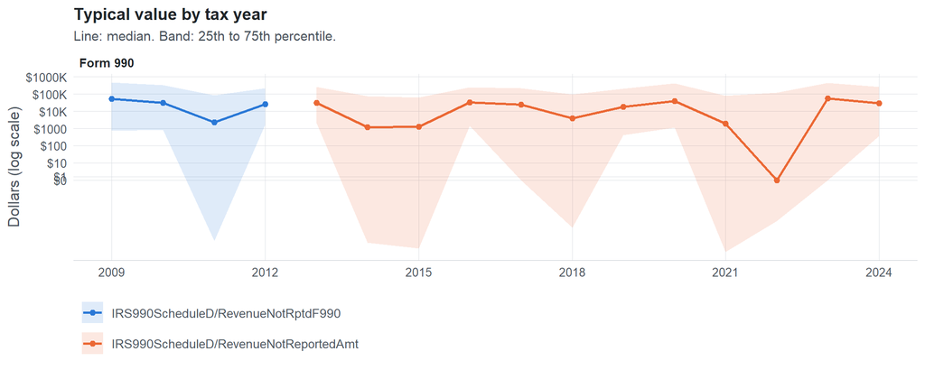

**Table view**

Table view: quartiles by tax year

| Series | Return | Tax year | Filings | P25 | Median | P75 |
| --- | --- | --- | --- | --- | --- | --- |
| IRS990ScheduleD/RevenueNotRptdF990 | 990 | 2009 | 18,048 | 740.24 | 54,303 | 480,422 |
| IRS990ScheduleD/RevenueNotRptdF990 | 990 | 2010 | 44,923 | 850.13 | 30,946 | 332,818 |
| IRS990ScheduleD/RevenueNotRptdF990 | 990 | 2011 | 55,135 | -3,334 | 2,290 | 82,628 |
| IRS990ScheduleD/RevenueNotRptdF990 | 990 | 2012 | 59,912 | 1,673 | 25,322 | 220,964 |
| IRS990ScheduleD/RevenueNotReportedAmt | 990 | 2013 | 63,755 | 1,995 | 31,273 | 265,912 |
| IRS990ScheduleD/RevenueNotReportedAmt | 990 | 2014 | 67,658 | -4,211 | 1,166 | 73,496 |
| IRS990ScheduleD/RevenueNotReportedAmt | 990 | 2015 | 70,352 | -9,033 | 1,233 | 62,499 |
| IRS990ScheduleD/RevenueNotReportedAmt | 990 | 2016 | 71,602 | 1,445 | 32,550 | 243,296 |
| IRS990ScheduleD/RevenueNotReportedAmt | 990 | 2017 | 75,814 | 0 | 25,126 | 216,891 |
| IRS990ScheduleD/RevenueNotReportedAmt | 990 | 2018 | 75,130 | -556.38 | 3,913 | 96,259 |
| IRS990ScheduleD/RevenueNotReportedAmt | 990 | 2019 | 75,537 | 408.66 | 18,720 | 210,706 |
| IRS990ScheduleD/RevenueNotReportedAmt | 990 | 2020 | 79,786 | 1,132 | 40,349 | 419,769 |
| IRS990ScheduleD/RevenueNotReportedAmt | 990 | 2021 | 80,355 | -14,948 | 1,958 | 78,812 |
| IRS990ScheduleD/RevenueNotReportedAmt | 990 | 2022 | 80,537 | -231.60 | 0 | 122,526 |
| IRS990ScheduleD/RevenueNotReportedAmt | 990 | 2023 | 79,850 | 0 | 55,971 | 432,997 |
| IRS990ScheduleD/RevenueNotReportedAmt | 990 | 2024 | 55,878 | 372.48 | 29,003 | 268,542 |

Summary by xpath and return type (all years)

| Series | Return | Filings | % numeric | % zero | % negative | Median (typical year) | P99 (typical year) |
| --- | --- | --- | --- | --- | --- | --- | --- |
| IRS990ScheduleD/RevenueNotRptdF990 | 990 | 178,018 | 100 | 28.0 | 11.8 | 41036 | 25005103 |
| IRS990ScheduleD/RevenueNotReportedAmt | 990 | 876,254 | 100 | 27.1 | 15.1 | 16908 | 19435143 |

## Examples

| Tax year | Return | Xpath | Organization | Value | Source |
| --- | --- | --- | --- | --- | --- |
| 2024 | 990 | IRS990ScheduleD/RevenueNotReportedAmt | YOUNG MEN’S CHRISTIAN ASSOCIATION | 8530 | [XML](https://gt990datalake-rawdata.s3.amazonaws.com/EfileData/XmlFiles/202541679349300439_public.xml) |
| 2023 | 990 | IRS990ScheduleD/RevenueNotReportedAmt | ZEPF CENTER | 137170 | [XML](https://gt990datalake-rawdata.s3.amazonaws.com/EfileData/XmlFiles/202423399349300887_public.xml) |
| 2022 | 990 | IRS990ScheduleD/RevenueNotReportedAmt | CANTERBURY TOWER INC | -2435481 | [XML](https://gt990datalake-rawdata.s3.amazonaws.com/EfileData/XmlFiles/202332979349301963_public.xml) |
| 2021 | 990 | IRS990ScheduleD/RevenueNotReportedAmt | COULEE REGION HUMANE SOCIETY INC | 532514 | [XML](https://gt990datalake-rawdata.s3.amazonaws.com/EfileData/XmlFiles/202243119349301379_public.xml) |
| 2020 | 990 | IRS990ScheduleD/RevenueNotReportedAmt | PROJECT ALLAHU AKBAR | 0 | [XML](https://gt990datalake-rawdata.s3.amazonaws.com/EfileData/XmlFiles/202103199349300805_public.xml) |
| 2019 | 990 | IRS990ScheduleD/RevenueNotReportedAmt | FRIENDS OF PEB INC | 0 | [XML](https://gt990datalake-rawdata.s3.amazonaws.com/EfileData/XmlFiles/202013109349302416_public.xml) |
| 2018 | 990 | IRS990ScheduleD/RevenueNotReportedAmt | UA LOCAL NO 159 | 153316 | [XML](https://gt990datalake-rawdata.s3.amazonaws.com/EfileData/XmlFiles/202000509349301025_public.xml) |
| 2017 | 990 | IRS990ScheduleD/RevenueNotReportedAmt | ALBERT LEA TRADES & LABOR ASSEMBLY | 0 | [XML](https://gt990datalake-rawdata.s3.amazonaws.com/EfileData/XmlFiles/201912279349302731_public.xml) |
| 2016 | 990 | IRS990ScheduleD/RevenueNotReportedAmt | Bellin Psychiatric Center | -413254 | [XML](https://gt990datalake-rawdata.s3.amazonaws.com/EfileData/XmlFiles/201812279349301906_public.xml) |
| 2015 | 990 | IRS990ScheduleD/RevenueNotReportedAmt | FIAT LUX RISK AND INSURANCE COMPANY | -368538 | [XML](https://gt990datalake-rawdata.s3.amazonaws.com/EfileData/XmlFiles/201721329349305242_public.xml) |
| 2014 | 990 | IRS990ScheduleD/RevenueNotReportedAmt | AMERICAN FED OF STATE CNTY AND MUNI | -35953 | [XML](https://gt990datalake-rawdata.s3.amazonaws.com/EfileData/XmlFiles/201513169349306271_public.xml) |
| 2013 | 990 | IRS990ScheduleD/RevenueNotReportedAmt | THE COUNCIL ON ALCOHOLISM & DRUG | 878 | [XML](https://gt990datalake-rawdata.s3.amazonaws.com/EfileData/XmlFiles/201441989349300024_public.xml) |

## Reviewer checklist

- The definition matches the form line and instructions for every xpath’s schema years.
- Every xpath pooled here measures the same thing on the 990 and 990-EZ (close enough for analysis).
- The coverage chart has no unexplained gaps or jumps between tax years.
- Each open flag is fixed, or accepted with a note in validation_log.csv.
- Values are whole dollars, not thousands, and not a percentage.
- Current year / prior year and beginning / end of year match the variable name (CY, PY, BOY, EOY).
- Negative values are expected only for net amounts (gains, net income, fund balances).
- The 990 and 990-EZ medians differ only as much as the filer populations do.

Record the review as a row in `inst/extdata/src/validation_log.csv` (variable_name, reviewer, date, status, note). Evidence built 2026-09-23 17:09:04 MST from the ef2 DuckDB builds (tax years 2009–2024).